# Laptop Value

```r
laptops2$Price_dollars <- laptops2$Price_euros*1.137
Dell <- subset(laptops2, Company=="Dell" & Inches=="13.3" & Ram=="8GB")

Dell.laptop.lm <- lm(Price_dollars ~ MemorySize, data=Dell)
plot(Price_dollars ~ MemorySize, data=Dell, col="red", main="Dell Laptops", ylab="Price in US dollars", xlab="Memory Size in GB")
abline(Dell.laptop.lm, col="Red")

predict(Dell.laptop.lm, data.frame(MemorySize = 238))
```

```
##        1
## 1520.256
```

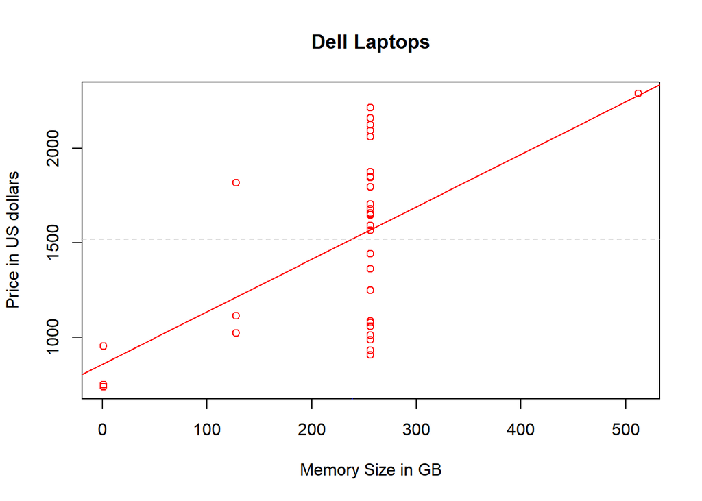

```r
abline(h=1520.256,col="gray",lty=2)
points(238,650, col="blue", pch="16")
```

The following is an equation of my regression model. The response variable is the price in US dollars, and the explanatory variable is the memory size.

$${\overbrace{Y_i}}^{\text{Price}} = {859.8} + {2.775}{\overbrace{X_i}}^{\text{Memory}} + \epsilon_i$$

### Technical Details

The null and alternative hypotheses for this linear regression are as follows

$$H_0: \beta_1 = 0$$
$$H_a: \beta_1 \neq 0$$
with a significance level of

$$\alpha = 0.05$$
The p-value 0.0004408 for the slope or $\beta_1$ is less than 0.05 so it is significant. We have sufficient evidence to say that the slope or $\beta_1$ does not equal zero.

```r
pander(summary(Dell.laptop.lm))
```

|  | Estimate | Std. Error | t value | Pr(>\|t\|) |
| --- | --- | --- | --- | --- |
| **(Intercept)** | 859.8 | 176 | 4.885 | 2.588e-05 |
| **MemorySize** | 2.775 | 0.7107 | 3.905 | 0.0004408 |

Fitting linear model: Price_dollars ~ MemorySize

| Observations | Residual Std. Error | $R^2$ | Adjusted $R^2$ |
| --- | --- | --- | --- |
| 35 | 380.7 | 0.316 | 0.2953 |

According to the diagnostic plots I would say that some of the assumptions for a linear regression have not been meet. The constant variance appears to be violated, and the normality of the error terms is questionable. The error terms appear to be independent.

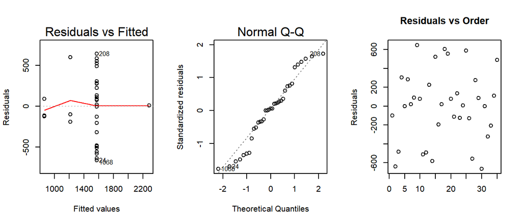

```r
par(mfrow=c(1,3))
plot(Dell.laptop.lm, which=1:2)
plot(Dell.laptop.lm$residuals, main="Residuals vs Order", xlab="", ylab="Residuals")
```